# A walk through modeling

Nicolas Delhomme

2021-05-17

From [Julian’s Faraway book: Linear Models with R](http://www.utstat.toronto.edu/~brunner/books/LinearModelsWithR.pdf), chapter 11.

```r
install.packages("faraway")
```

# 1 Intro

Verbatim from the book

"In this chapter, we present a relatively complete data analysis. The example is interesting because it illustrates several of the ambiguities and difficulties encountered in statistical practice.

Insurance redlining refers to the practice of refusing to issue insurance to certain types of people or within some geographic area. The name comes from the act of drawing a red line around an area on a map. Now few would quibble with an insurance company refusing to sell auto insurance to a frequent drunk driver, but other forms of discrimination would be unacceptable.

In the late 1970s, the U.S. Commission on Civil Rights examined charges by several Chicago community organizations that insurance companies were redlining their neighborhoods. Because comprehensive information about individuals being refused homeowners insurance was not available, the number of FAIR plan policies written and renewed in Chicago by zip code for the months of December 1977 through May 1978 was recorded. The FAIR plan was offered by the city of Chicago as a default policy to homeowners who had been rejected by the voluntary market. Information on other variables that might affect insurance writing such as fire and theft rates were also collected at the zip code level. The variables are:

- race racial composition in percentage of minority
- fire fires per 100 housing units
- theft theft per 1000 population
- age percentage of housing units built before 1939
- involact new FAIR plan policies and renewals per 100 housing units
- income median family income in thousands of dollars
- side North or South Side of Chicago

The data come from Andrews and Herzberg (1985) where more details of the variables and the background are provided."

# 2 The data

```r
library(faraway)
data (chredlin)
chredlin
```

```
##       race fire theft  age involact income side
## 60626 10.0  6.2    29 60.4      0.0 11.744    n
## 60640 22.2  9.5    44 76.5      0.1  9.323    n
## 60613 19.6 10.5    36 73.5      1.2  9.948    n
## 60657 17.3  7.7    37 66.9      0.5 10.656    n
## 60614 24.5  8.6    53 81.4      0.7  9.730    n
## 60610 54.0 34.1    68 52.6      0.3  8.231    n
## 60611  4.9 11.0    75 42.6      0.0 21.480    n
## 60625  7.1  6.9    18 78.5      0.0 11.104    n
## 60618  5.3  7.3    31 90.1      0.4 10.694    n
## 60647 21.5 15.1    25 89.8      1.1  9.631    n
## 60622 43.1 29.1    34 82.7      1.9  7.995    n
## 60631  1.1  2.2    14 40.2      0.0 13.722    n
## 60646  1.0  5.7    11 27.9      0.0 16.250    n
## 60656  1.7  2.0    11  7.7      0.0 13.686    n
```

[output cut: 33 more lines]

```r
summary(chredlin)
```

```
##       race            fire           theft             age
##  Min.   : 1.00   Min.   : 2.00   Min.   :  3.00   Min.   : 2.00
##  1st Qu.: 3.75   1st Qu.: 5.65   1st Qu.: 22.00   1st Qu.:48.60
##  Median :24.50   Median :10.40   Median : 29.00   Median :65.00
##  Mean   :34.99   Mean   :12.28   Mean   : 32.36   Mean   :60.33
##  3rd Qu.:57.65   3rd Qu.:16.05   3rd Qu.: 38.00   3rd Qu.:77.30
##  Max.   :99.70   Max.   :39.70   Max.   :147.00   Max.   :90.10
##     involact          income       side
##  Min.   :0.0000   Min.   : 5.583   n:25
##  1st Qu.:0.0000   1st Qu.: 8.447   s:22
##  Median :0.4000   Median :10.694
##  Mean   :0.6149   Mean   :10.696
##  3rd Qu.:0.9000   3rd Qu.:11.989
##  Max.   :2.2000   Max.   :21.480
```

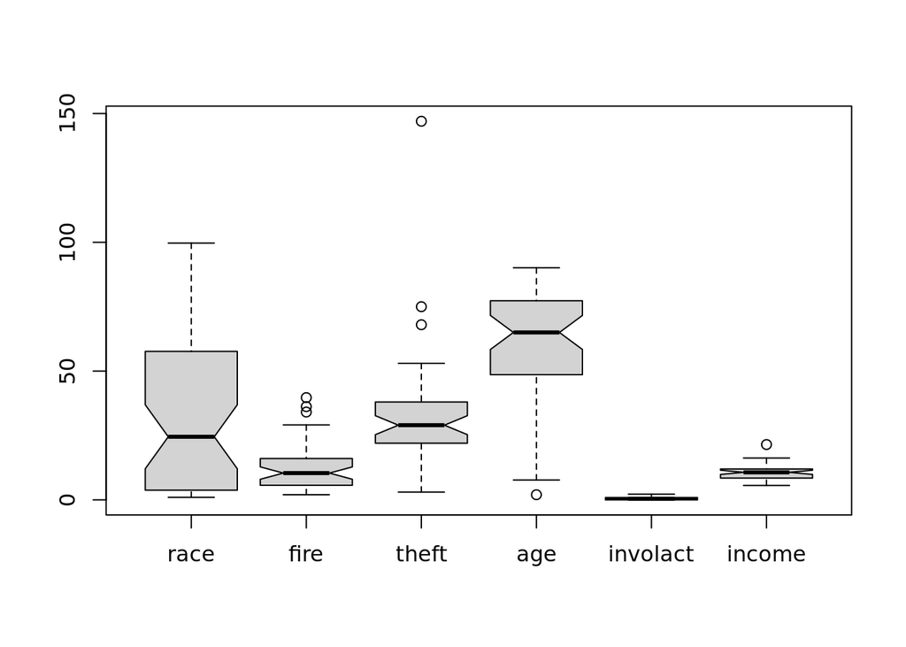

```r
boxplot(chredlin[,1:6],notch = TRUE)
```

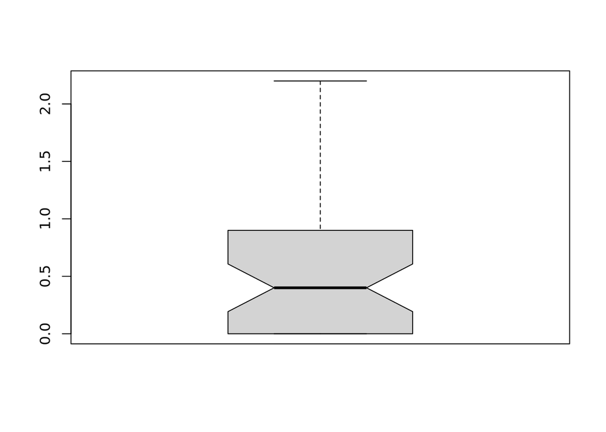

```r
boxplot(chredlin[,5],notch = TRUE)
```

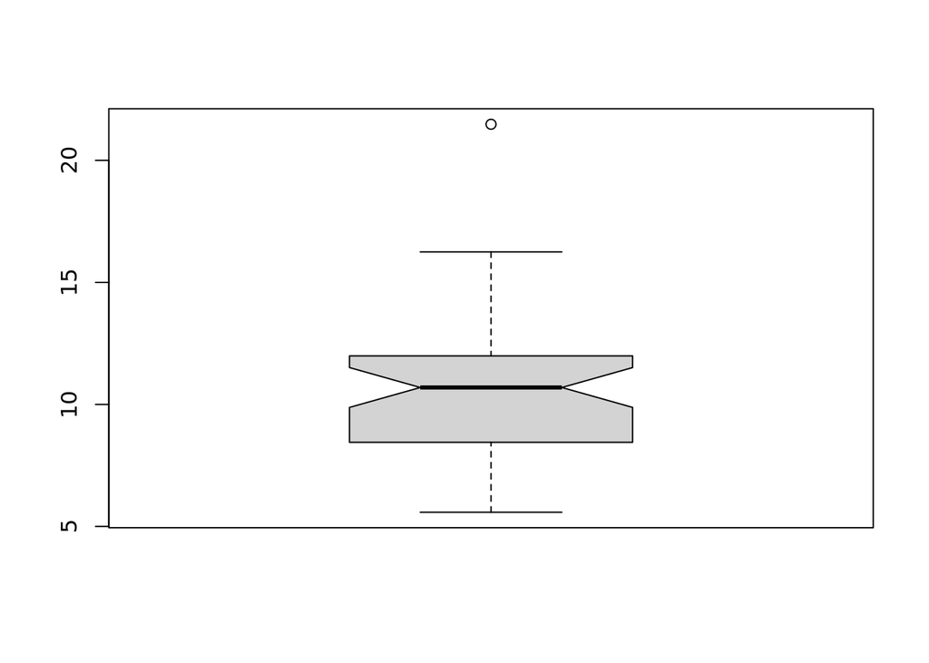

```r
boxplot(chredlin[,6],notch = TRUE)
```

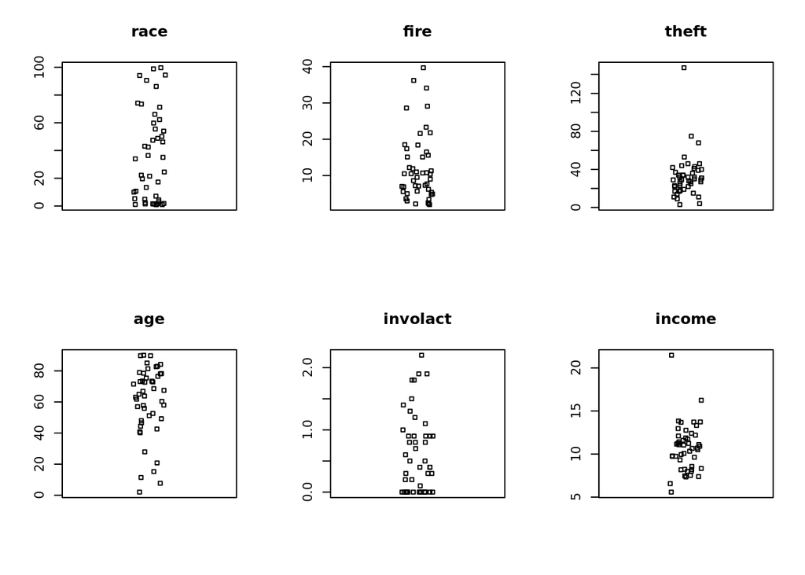

```r
par(mfrow=c (2, 3))
for (i in 1:6) stripchart (chredlin [, i], main=names(chredlin) [i], vertical=TRUE,method="jitter")
```

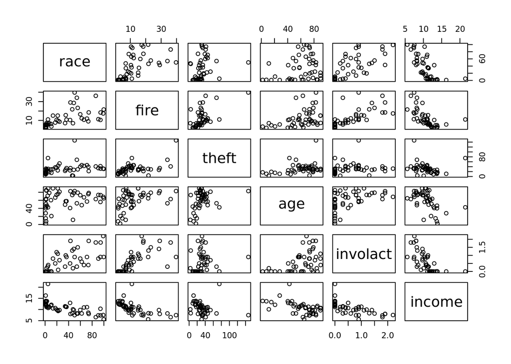

```r
par(mfrow=c (1, 1))
pairs (chredlin[,1:6])
```

# 3 Testing

## 3.1 Simpler model

```r
summary (lm (involact~race, chredlin))
```

```
##
## Call:
## lm(formula = involact ~ race, data = chredlin)
##
## Residuals:
##     Min      1Q  Median      3Q     Max
## -0.7496 -0.2479 -0.1487  0.3129  1.1724
##
## Coefficients:
##             Estimate Std. Error t value Pr(>|t|)
## (Intercept) 0.129218   0.096611   1.338    0.188
## race        0.013882   0.002031   6.836 1.78e-08 ***
## ---
## Signif. codes:  0 '***' 0.001 '**' 0.01 '*' 0.05 '.' 0.1 ' ' 1
##
## Residual standard error: 0.4488 on 45 degrees of freedom
## Multiple R-squared:  0.5094, Adjusted R-squared:  0.4985
## F-statistic: 46.73 on 1 and 45 DF,  p-value: 1.784e-08
```

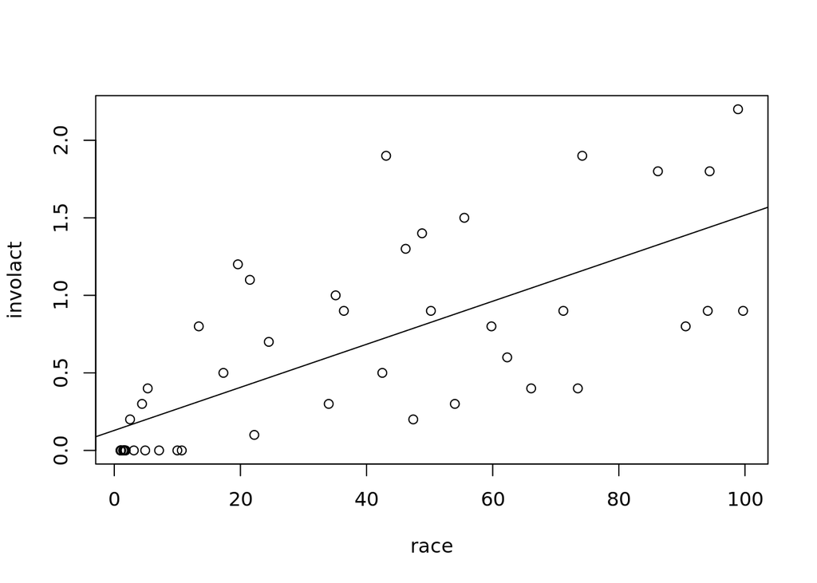

```r
plot (involact~race, chredlin)
abline (lm (involact~race, chredlin))
```

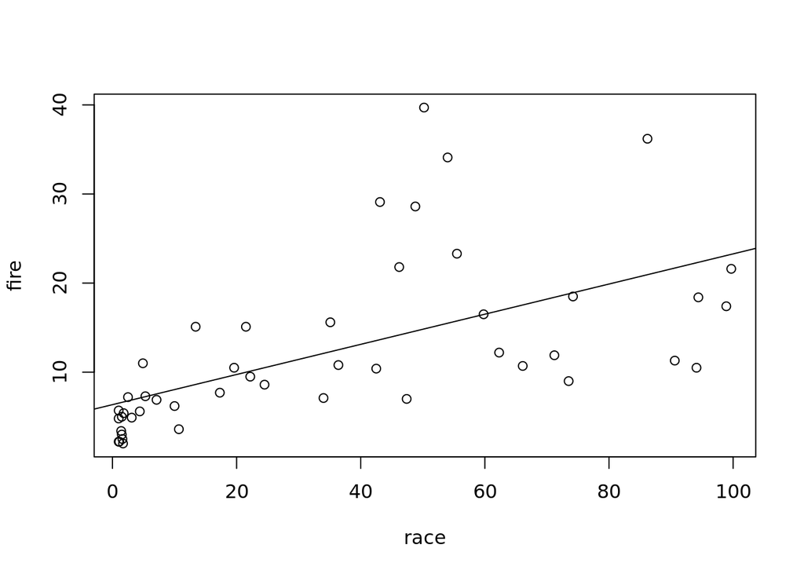

```r
plot (fire~race, chredlin)
abline (lm (fire~ race, chredlin))
```

## 3.2 Complete model

```r
g <- lm (involact ~ race+ fire + theft + age + log(income)  ,chredlin)
summary (g)
```

```
##
## Call:
## lm(formula = involact ~ race + fire + theft + age + log(income),
##     data = chredlin)
##
## Residuals:
##      Min       1Q   Median       3Q      Max
## -0.85393 -0.16922 -0.03088  0.17890  0.81228
##
## Coefficients:
##              Estimate Std. Error t value Pr(>|t|)
## (Intercept) -1.185540   1.100255  -1.078 0.287550
## race         0.009502   0.002490   3.817 0.000449 ***
## fire         0.039856   0.008766   4.547 4.76e-05 ***
## theft       -0.010295   0.002818  -3.653 0.000728 ***
## age          0.008336   0.002744   3.038 0.004134 **
## log(income)  0.345762   0.400123   0.864 0.392540
## ---
## Signif. codes:  0 '***' 0.001 '**' 0.01 '*' 0.05 '.' 0.1 ' ' 1
##
## Residual standard error: 0.3345 on 41 degrees of freedom
## Multiple R-squared:  0.7517, Adjusted R-squared:  0.7214
## F-statistic: 24.83 on 5 and 41 DF,  p-value: 2.009e-11
```

```r
gs <- g
```

### 3.2.1 Assessment

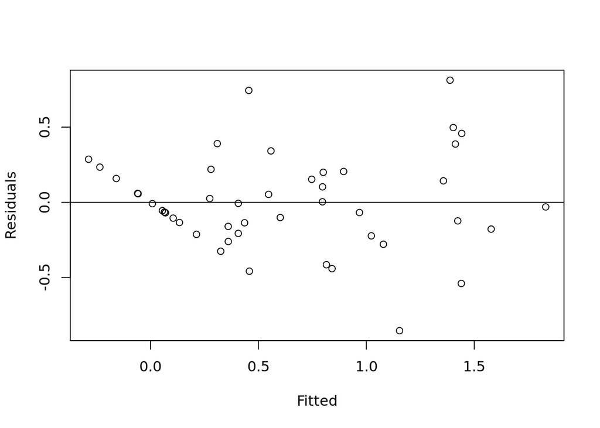

```r
plot (fitted (g), residuals (g), xlab="Fitted", ylab="Residuals")
abline (h=0)
```

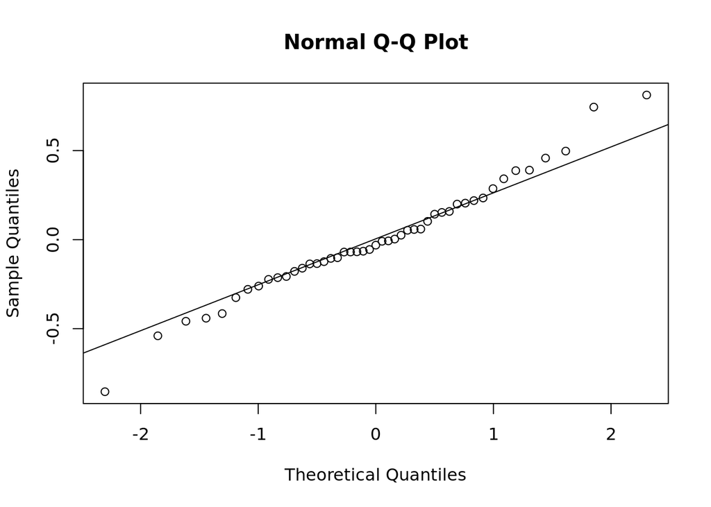

```r
qqnorm (residuals (g))
qqline (residuals (g))
```

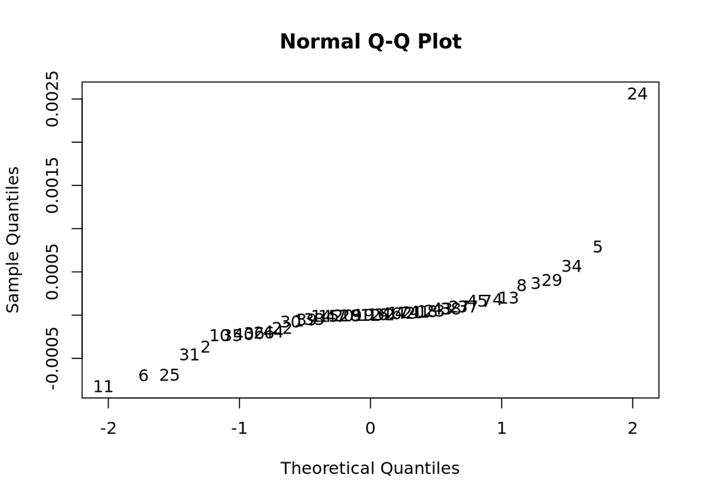

```r
gi <- influence (g)
qqnorml (gi$coef[,4])
```

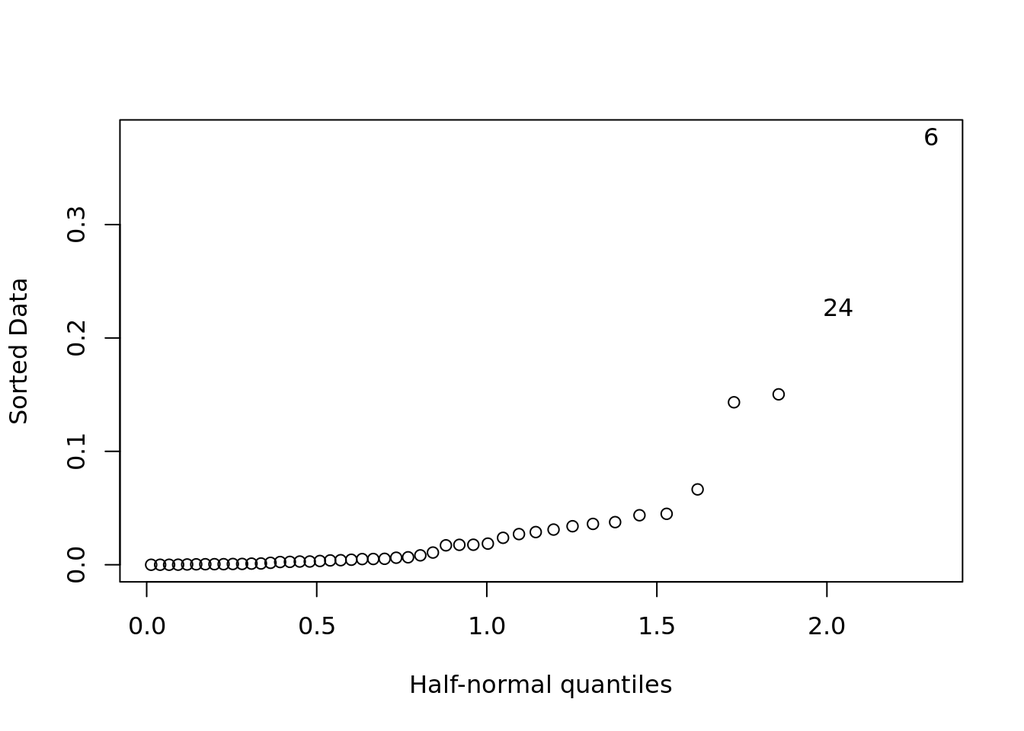

```r
halfnorm(cooks.distance(g))
```

```r
range(rstudent(g))
```

```
## [1] -3.184960  2.792884
```

### 3.2.2 Outliers

```r
chredlin[c(6,24),]
```

```
##       race fire theft  age involact income side
## 60610 54.0 34.1    68 52.6      0.3  8.231    n
## 60607 50.2 39.7   147 83.0      0.9  7.459    n
```

## 3.3 Reduced model

```r
g <- lm(involact~race + fire + theft + age + log(income), chredlin,subset = -c(6,24))
summary(g)
```

```
##
## Call:
## lm(formula = involact ~ race + fire + theft + age + log(income),
##     data = chredlin, subset = -c(6, 24))
##
## Residuals:
##      Min       1Q   Median       3Q      Max
## -0.63445 -0.21208 -0.02757  0.15580  0.83307
##
## Coefficients:
##              Estimate Std. Error t value Pr(>|t|)
## (Intercept) -0.576737   1.080046  -0.534   0.5964
## race         0.007053   0.002696   2.616   0.0126 *
## fire         0.049647   0.008570   5.793    1e-06 ***
## theft       -0.006434   0.004349  -1.479   0.1471
## age          0.005171   0.002895   1.786   0.0818 .
## log(income)  0.115703   0.401113   0.288   0.7745
## ---
## Signif. codes:  0 '***' 0.001 '**' 0.01 '*' 0.05 '.' 0.1 ' ' 1
##
## Residual standard error: 0.3032 on 39 degrees of freedom
## Multiple R-squared:  0.8041, Adjusted R-squared:  0.779
## F-statistic: 32.01 on 5 and 39 DF,  p-value: 8.192e-13
```

### 3.3.1 Assessment

Need for transformation?

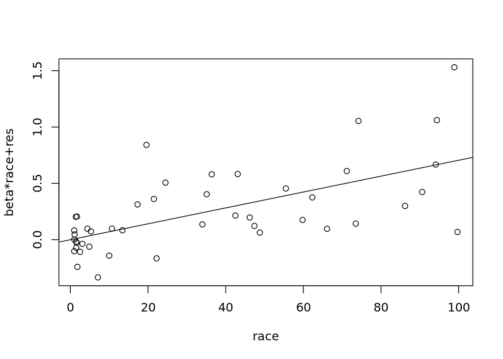

```r
prplot (g, 1)
```

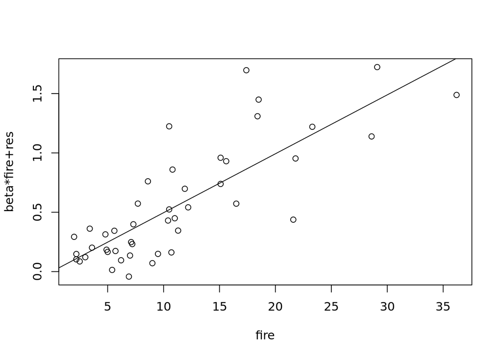

```r
prplot (g, 2)
```

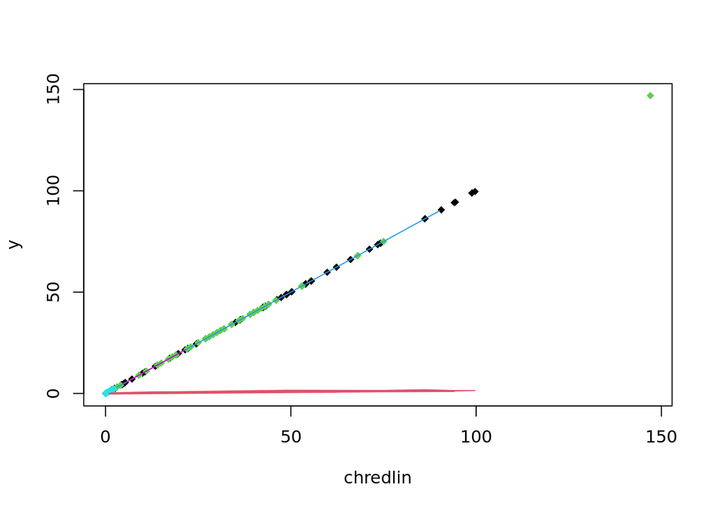

```r
chreduc <- matplot(chredlin, cbind(chredlin, gs$fit), type="pl", ylab="y", pch=18, lty=1)
```

```r
install.packages("leaps")
```

```r
library(leaps)
(b <- regsubsets(involact ~ race + fire + theft + age + log(income), force.in=1, data=chredlin[-c(6,24),]))
```

```
## Subset selection object
## Call: regsubsets.formula(involact ~ race + fire + theft + age + log(income),
##     force.in = 1, data = chredlin[-c(6, 24), ])
## 5 Variables  (and intercept)
##             Forced in Forced out
## race             TRUE      FALSE
## fire            FALSE      FALSE
## theft           FALSE      FALSE
## age             FALSE      FALSE
## log(income)     FALSE      FALSE
## 1 subsets of each size up to 5
## Selection Algorithm: exhaustive
```

```r
(rs <- summary(b))
```

```
## Subset selection object
## Call: regsubsets.formula(involact ~ race + fire + theft + age + log(income),
##     force.in = 1, data = chredlin[-c(6, 24), ])
## 5 Variables  (and intercept)
##             Forced in Forced out
## race             TRUE      FALSE
## fire            FALSE      FALSE
## theft           FALSE      FALSE
## age             FALSE      FALSE
## log(income)     FALSE      FALSE
## 1 subsets of each size up to 5
## Selection Algorithm: exhaustive
##          race fire theft age log(income)
## 2  ( 1 ) "*"  "*"  " "   " " " "
## 3  ( 1 ) "*"  "*"  " "   "*" " "
## 4  ( 1 ) "*"  "*"  "*"   "*" " "
## 5  ( 1 ) "*"  "*"  "*"   "*" "*"
```

```r
rs$adjr2
```

```
## [1] 0.7685506 0.7764969 0.7840178 0.7789514
```

## 3.4 Best model (?)

```r
g <- lm (involact~ race + fire + theft + age, chredlin,subset= -c(6,24))
summary(g)
```

```
##
## Call:
## lm(formula = involact ~ race + fire + theft + age, data = chredlin,
##     subset = -c(6, 24))
##
## Residuals:
##     Min      1Q  Median      3Q     Max
## -0.6634 -0.2159 -0.0303  0.1665  0.8368
##
## Coefficients:
##              Estimate Std. Error t value Pr(>|t|)
## (Intercept) -0.267870   0.139668  -1.918  0.06228 .
## race         0.006489   0.001837   3.532  0.00105 **
## fire         0.049057   0.008226   5.963 5.32e-07 ***
## theft       -0.005809   0.003728  -1.558  0.12709
## age          0.004688   0.002334   2.009  0.05136 .
## ---
## Signif. codes:  0 '***' 0.001 '**' 0.01 '*' 0.05 '.' 0.1 ' ' 1
##
## Residual standard error: 0.2997 on 40 degrees of freedom
## Multiple R-squared:  0.8037, Adjusted R-squared:  0.784
## F-statistic: 40.93 on 4 and 40 DF,  p-value: 1.238e-13
```

### 3.4.1 Alternatives

```r
galt <- lm(involact ~ race+fire+log(income), chredlin,subset= -c(6, 24))
summary (galt)
```

```
##
## Call:
## lm(formula = involact ~ race + fire + log(income), data = chredlin,
##     subset = -c(6, 24))
##
## Residuals:
##      Min       1Q   Median       3Q      Max
## -0.75148 -0.19280 -0.00621  0.11072  0.87411
##
## Coefficients:
##              Estimate Std. Error t value Pr(>|t|)
## (Intercept)  0.753256   0.835880   0.901   0.3728
## race         0.004206   0.002276   1.848   0.0718 .
## fire         0.051022   0.008450   6.038 3.82e-07 ***
## log(income) -0.362382   0.319162  -1.135   0.2628
## ---
## Signif. codes:  0 '***' 0.001 '**' 0.01 '*' 0.05 '.' 0.1 ' ' 1
##
## Residual standard error: 0.3092 on 41 degrees of freedom
## Multiple R-squared:  0.7858, Adjusted R-squared:  0.7701
## F-statistic: 50.14 on 3 and 41 DF,  p-value: 8.873e-14
```

```r
galt <- lm(involact~ race+fire, chredlin, subset=-c(6, 24))
summary(galt)
```

```
##
## Call:
## lm(formula = involact ~ race + fire, data = chredlin, subset = -c(6,
##     24))
##
## Residuals:
##      Min       1Q   Median       3Q      Max
## -0.65891 -0.20471 -0.01654  0.13807  0.87525
##
## Coefficients:
##              Estimate Std. Error t value Pr(>|t|)
## (Intercept) -0.191325   0.081517  -2.347  0.02371 *
## race         0.005712   0.001856   3.078  0.00366 **
## fire         0.054664   0.007845   6.968 1.61e-08 ***
## ---
## Signif. codes:  0 '***' 0.001 '**' 0.01 '*' 0.05 '.' 0.1 ' ' 1
##
## Residual standard error: 0.3103 on 42 degrees of freedom
## Multiple R-squared:  0.7791, Adjusted R-squared:  0.7686
## F-statistic: 74.05 on 2 and 42 DF,  p-value: 1.696e-14
```

```r
g <- lm(involact~race + fire + theft + age, chredlin)
summary (g)
```

```
##
## Call:
## lm(formula = involact ~ race + fire + theft + age, data = chredlin)
##
## Residuals:
##      Min       1Q   Median       3Q      Max
## -0.87108 -0.14830 -0.01961  0.19968  0.81638
##
## Coefficients:
##              Estimate Std. Error t value Pr(>|t|)
## (Intercept) -0.243118   0.145054  -1.676 0.101158
## race         0.008104   0.001886   4.297 0.000100 ***
## fire         0.036646   0.007916   4.629 3.51e-05 ***
## theft       -0.009592   0.002690  -3.566 0.000921 ***
## age          0.007210   0.002408   2.994 0.004595 **
## ---
## Signif. codes:  0 '***' 0.001 '**' 0.01 '*' 0.05 '.' 0.1 ' ' 1
##
## Residual standard error: 0.3335 on 42 degrees of freedom
## Multiple R-squared:  0.7472, Adjusted R-squared:  0.7231
## F-statistic: 31.03 on 4 and 42 DF,  p-value: 4.799e-12
```